# Проблема второй и третьей смены в российских школах

# Исследовательский вопрос

Какая связь доли детей в регионе, обучающихся во вторую и третью смену, с такими инфраструктурными факторами, как нагрузка на учителя, учебная площадь, число посадочных мест в столовой, финансирование в расчете на одного ребенка?

# Актуальность

В ряде психологических и физиологических исследований уже давно отмечено, что из-за нарушения режима обучения, которое вызвано второй и третьей сменой, может нарушиться развитие и здоровье детей младшего школьного возраста. При этом, согласно докладу Правительства о реализации государственной политики в сфере образования в 2019 году отмечается, что число школьников, обучающихся во вторую смену выросло до 2,1 млн человек, а в третью до 22,8 тыс. человек. Также в проведенном опросе Н.С. Козиной, Д.К. Дехант выяснилось, что около четверти (27%) опрошенных директоров считают, что проблема со второй сменой уже существует, 29%, по мнению 44% респондентов, данная проблема не затронет их образовательную организацию. Таким образом, проблема с устранением второй и третьей смены в настоящее время не решена. На федеральном уровне запущена программа по созданию дополнительных мест и планируется к 2025 году окончательно решить эту проблему. Несмотря на это, одной меры по созданию новых мест недостаточно, так как в школах выделяются факторы: количество учеников на одного педагога, финансирование в расчете на одного ученика, учебная площадь в расчета не одного ученика, число посадочных мест в столовой.

# Методология

Для ответа на исследовательский вопрос будет использована линейная регрессия: проведено моделирование отношений между несколькими независимыми переменными (нагрузка на учителя, учебная площадь, число посадочных мест в столовой, финансирование в расчете на одного ребенка) и прогнозируемым значением доли детей в регионе, обучающихся во вторую и третью смену.

*Подгружаем пакеты*

```r
.libPaths(c('C:/Rtools/R',.libPaths()))
library(ggplot2)
library(tidyverse)
library(sjPlot)
library(skimr)
library(car)
library(jtools)
```

# Описание данных и переменных

smena - удельный вес учеников, обучающихся в вторую и третью смену смену, %;

ped - количество учеников на одного педагога, чел.;

fin - финансирование в расчёте на одного ученика, тыс.руб/чел.;

sq - учебная площадь в расчете на одного ученика, м2/чел.;

lun - число посадочных мест в столовой в расчете на одного ученика, мест/чел.

*Пропущенные значение и миссинги отсутсвуют. Все переменные определены как числовые.*

*Подгружаем данные*

```r
data <- read.table(file = "data.csv", header = TRUE, sep = ";", dec = ",")
```

## Описание данных

```r
skim(data$smena)
```

Data summary

| Name | data$smena |
| --- | --- |
| Number of rows | 85 |
| Number of columns | 1 |
| _______________________ |  |
| Column type frequency: |  |
| numeric | 1 |
| ________________________ |  |
| Group variables | None |

**Variable type: numeric**

| skim_variable | n_missing | complete_rate | mean | sd | p0 | p25 | p50 | p75 | p100 | hist |
| --- | --- | --- | --- | --- | --- | --- | --- | --- | --- | --- |
| data | 0 | 1 | 12.72 | 7.67 | 0 | 7.92 | 10.97 | 17.58 | 38.49 | ▅▇▅▁▁ |

```r
skim(data$ped)
```

Data summary

| Name | data$ped |
| --- | --- |
| Number of rows | 85 |
| Number of columns | 1 |
| _______________________ |  |
| Column type frequency: |  |
| numeric | 1 |
| ________________________ |  |
| Group variables | None |

**Variable type: numeric**

| skim_variable | n_missing | complete_rate | mean | sd | p0 | p25 | p50 | p75 | p100 | hist |
| --- | --- | --- | --- | --- | --- | --- | --- | --- | --- | --- |
| data | 0 | 1 | 12.27 | 2.12 | 8 | 11 | 12 | 13 | 18 | ▅▇▇▂▁ |

*В среднем по стране на одного педагога приходится 12 учеников. В Кранодарском крае нагрузка значительно выше, на одного педагога приходится 18 учеников. При этом в малонаселенных регионах, нагрузка меньше: в Републике Калмыкия, Чукотском автономной округе и Республике Саха (якутия) на 1 педагога приходится 8 учеников.*

```r
skim(data$fin)
```

Data summary

| Name | data$fin |
| --- | --- |
| Number of rows | 85 |
| Number of columns | 1 |
| _______________________ |  |
| Column type frequency: |  |
| numeric | 1 |
| ________________________ |  |
| Group variables | None |

**Variable type: numeric**

| skim_variable | n_missing | complete_rate | mean | sd | p0 | p25 | p50 | p75 | p100 | hist |
| --- | --- | --- | --- | --- | --- | --- | --- | --- | --- | --- |
| data | 0 | 1 | 98.75 | 64.06 | 49.19 | 67.84 | 77.02 | 96.61 | 438.23 | ▇▁▁▁▁ |

*Финансирование образования в расчете на одного ребенка значительно отличается по регионам (sd=64 при mean=98.75). Самымыми малообеспеченными являются южные республики: Республика Северная Осетия (49.19 тыс.руб/чел) и Чеченская Республика (51.65 тыс.руб/чел). Самое значительное финасирование в северных регионах, такие как Чукотский автономный округ (438.23 тыс.руб/чел), Ненецкий автономный округ (348.96 тыс.руб/чел), и в Москве (256.37 тыс.руб/чел).* *Следует отметить, что и стоимость жизни (стоимость продуктовой корзины) в регионах отличается. Поэтому на графике распределения можно отметить явную правостороннюю ассиметрию - север решает.*

```r
skim(data$sq)
```

Data summary

| Name | data$sq |
| --- | --- |
| Number of rows | 85 |
| Number of columns | 1 |
| _______________________ |  |
| Column type frequency: |  |
| numeric | 1 |
| ________________________ |  |
| Group variables | None |

**Variable type: numeric**

| skim_variable | n_missing | complete_rate | mean | sd | p0 | p25 | p50 | p75 | p100 | hist |
| --- | --- | --- | --- | --- | --- | --- | --- | --- | --- | --- |
| data | 0 | 1 | 4.78 | 0.97 | 2.85 | 3.99 | 4.79 | 5.34 | 7.93 | ▃▇▇▂▁ |

*В среднем по России на 1 ученика приходится почти 5кв.м учебной площади. При этом самые комфортные условия у учеников Москве - 7,93кв.м. на одного ученика. Самые стестенные условия у детей, проживающих на юге страны: в Чеченской Республике - 2.85кв.м на ученика, в Краснодарском крае - 3.21кв.м на ученика, Республика Дагестан - 3.31 кв.м на ученика.*

```r
skim(data$lun)
```

Data summary

| Name | data$lun |
| --- | --- |
| Number of rows | 85 |
| Number of columns | 1 |
| _______________________ |  |
| Column type frequency: |  |
| numeric | 1 |
| ________________________ |  |
| Group variables | None |

**Variable type: numeric**

| skim_variable | n_missing | complete_rate | mean | sd | p0 | p25 | p50 | p75 | p100 | hist |
| --- | --- | --- | --- | --- | --- | --- | --- | --- | --- | --- |
| data | 0 | 1 | 0.28 | 0.06 | 0.1 | 0.24 | 0.29 | 0.32 | 0.48 | ▁▆▇▅▁ |

*И что касается обеспеченностью местами в столовых, то лучше всего ситуация в Чукотском автономном округе, там на одного ребенка приходится 0.48 мест (или если говорить нормальным языком, то 1 посадочное место в столовой на 2 учеников). Самая сложная ситуация в южных регионах: в Чеченской Республике 1 посадочное место в столовой на 10 учеников и в Республике Ингушетия 1 место на 8 учеников.*

## Построим графики рассеяния

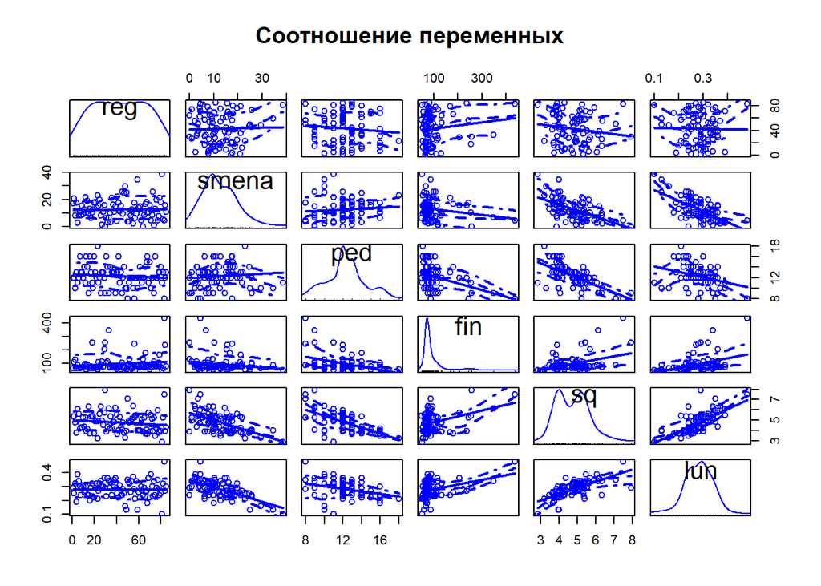

```r
scatterplotMatrix(data,spread = FALSE, lty.smooth = 2, main ='Соотношение переменных')
```

# Линейная регрессия

```r
model <- lm(data=data,smena~ped+fin+sq+lun)
summary(model)
```

```
##
## Call:
## lm(formula = smena ~ ped + fin + sq + lun, data = data)
##
## Residuals:
##      Min       1Q   Median       3Q      Max
## -19.0001  -2.6699  -0.4242   3.6543  12.0409
##
## Coefficients:
##              Estimate Std. Error t value Pr(>|t|)
## (Intercept)  61.89800    7.79647   7.939 1.06e-11 ***
## ped          -1.28063    0.39207  -3.266 0.001606 **
## fin           0.00348    0.01050   0.332 0.741103
## sq           -4.21284    1.10141  -3.825 0.000258 ***
## lun         -48.68794   14.09854  -3.453 0.000888 ***
## ---
## Signif. codes:  0 '***' 0.001 '**' 0.01 '*' 0.05 '.' 0.1 ' ' 1
##
## Residual standard error: 5.462 on 80 degrees of freedom
## Multiple R-squared:  0.5164, Adjusted R-squared:  0.4922
## F-statistic: 21.35 on 4 and 80 DF,  p-value: 5.205e-12
```

```r
confint(model)
```

```
##                    2.5 %       97.5 %
## (Intercept)  46.38253506  77.41345739
## ped          -2.06088581  -0.50038407
## fin          -0.01740939   0.02436969
## sq           -6.40471196  -2.02095776
## lun         -76.74492942 -20.63095796
```

# Оформим результаты в таблицу по требованиям APA

```r
tab_model(model,show.se = TRUE,
          show.stat = T)
```

|  | smena |  |  |  |  |
| --- | --- | --- | --- | --- | --- |
| Predictors | Estimates | std. Error | CI | Statistic | p |
| (Intercept) | 61.90 | 7.80 | 46.38 – 77.41 | 7.94 | **<0.001** |
| ped | -1.28 | 0.39 | -2.06 – -0.50 | -3.27 | **0.002** |
| fin | 0.00 | 0.01 | -0.02 – 0.02 | 0.33 | 0.741 |
| sq | -4.21 | 1.10 | -6.40 – -2.02 | -3.82 | **<0.001** |
| lun | -48.69 | 14.10 | -76.74 – -20.63 | -3.45 | **0.001** |
| Observations | 85 |  |  |  |  |
| R<sup>2</sup> / R<sup>2</sup> adjusted | 0.516 / 0.492 |  |  |  |  |

*Построена регрессионная модель вида:* *smena = 61,9 - 1.28 x ped - 4.21 x sq - 48.69 x lun*

*т.е. при увеличении нагрузки на учителя: увеличении на 1 чел.общего числа учеников, приходящихся на 1 педагога, доля детей в регионе, обучающихся в вторую и третью смену снизится на 1.28%*

*при увеличении учебной площади в расчете на одного обучающегося на 1 кв.м доля детей в регионе, обучающихся в вторую и третью смену снизится на 4.21%*

*при увеличении числа посадочных мест в столовой в расчете на одного обучающегося на 1, доля детей в регионе, обучающихся в вторую и третью смену снизится на 48.69% (но объективно, с точки зрения здравого смысла невозможно построить школу, в которой будет предусмотрено индивидуальное место в столовой для каждого ребенка.*

*Расчитанный коэффициент финансирования обучения (в расчете на 1 ученика) не является статистически значимым*

*Residual standard error: 5.462 on 80 degrees of freedom говорит нам о средней квадратической ошибке остатков.*

*О качестве модели свидетельствуют расчитанный коэффициент детерминации (Multiple R-squared) равный 0.51.Что свидетельсвует о невысоком уровне модели (т.к. только 51% вариации зависимой переменной объясняется вариацией независимых переменных).*

*Значимость среднеквадратичного отклонения подтверждает значение F-статистики, равное 21.35 и общий уровень значимости p-value: 5.205e-12, что меньше 0.001.*

# Диагностика модели

## Нормальность

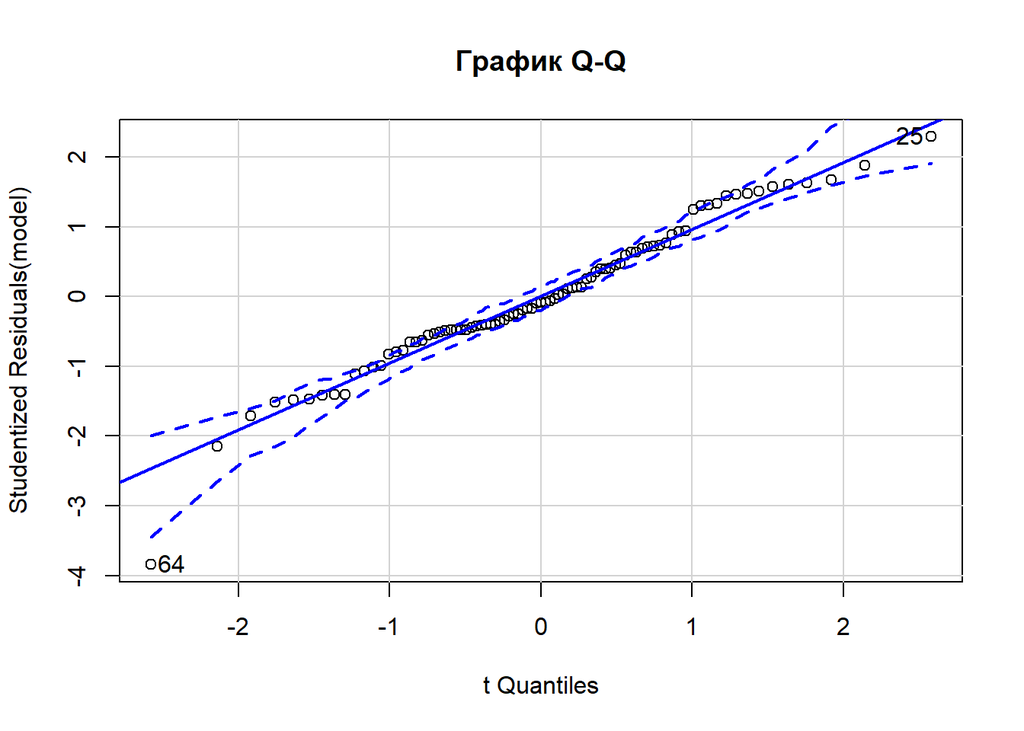

```
## [1] 25 64
```

```r
qqPlot(model, labels = row.names(model), simulate = TRUE, main = 'График Q-Q')
```

*Для определения нормальности распределения остатков построен QQ-plot: точки распределены по прямой с незначительными отклонениями на максимальных значениях (т.е высоки для нормального распределения) и минимальных значениях (соответсвенно значения меньше предстказанных). В целом можно сделать заключение о том, что анализируемая переменная (остатки) имеет нормальное распределение.*

## Линейность

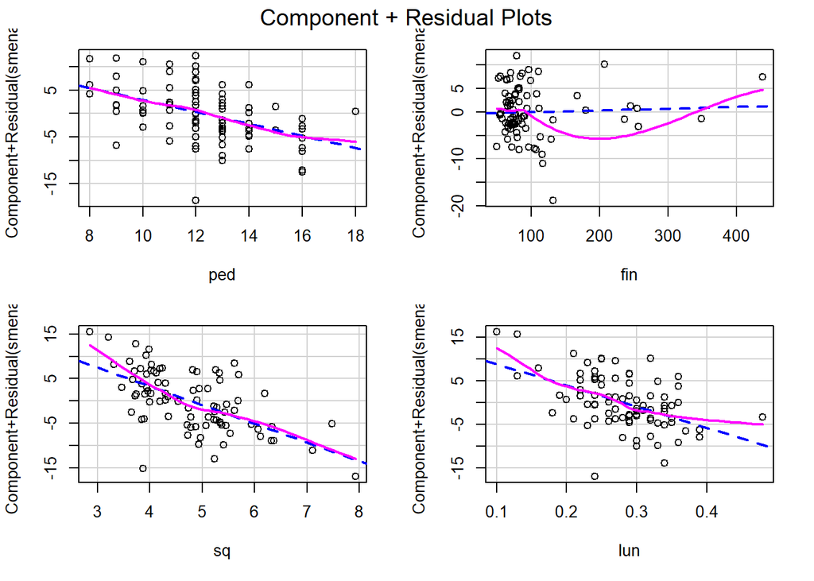

```r
crPlots((model))
```

## Гомокседаксичность

```r
ncvTest((model))
```

```
## Non-constant Variance Score Test
## Variance formula: ~ fitted.values
## Chisquare = 1.481489, Df = 1, p = 0.22354
```

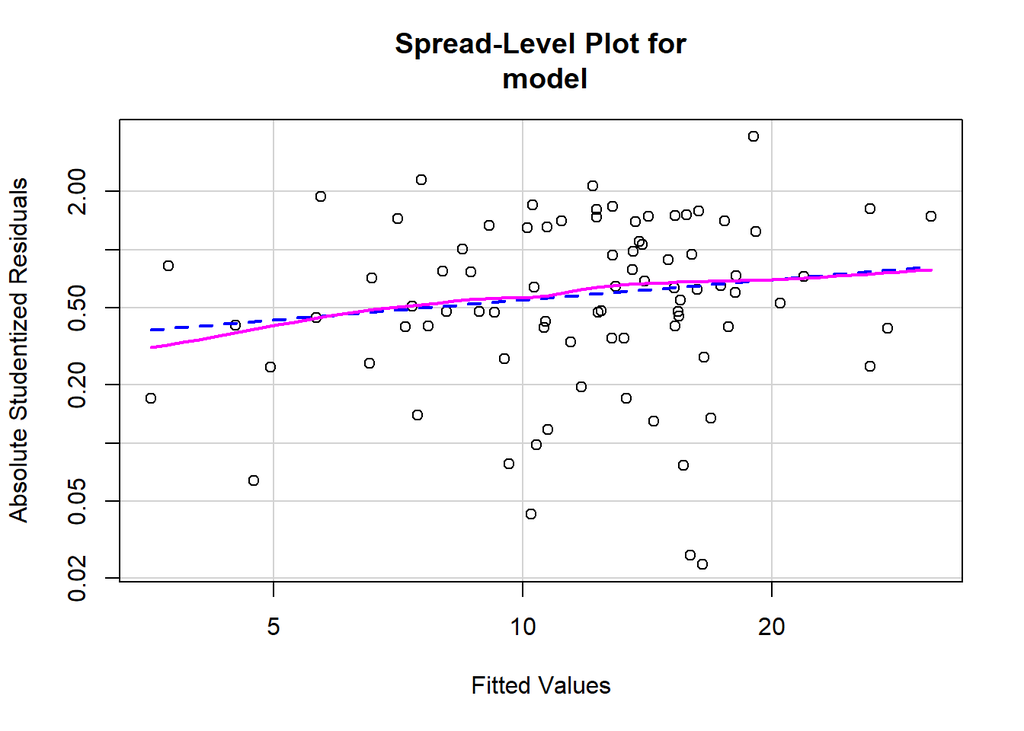

```
##
## Suggested power transformation:  0.6525402
```

```r
spreadLevelPlot(model)
```

*Для проверки гомоскедастичости построен график Scale-Location. Горизонтальная линия с равномерно распределенными точками является показателем гомоскедастичности.*

## Мультиколлинеарность

```r
vif(model)
```

```
##      ped      fin       sq      lun
## 1.941225 1.273034 3.183740 2.164105
```

```r
sqrt(vif(model))>2
```

```
##   ped   fin    sq   lun
## FALSE FALSE FALSE FALSE
```

*Для проверки мультиколлинеарности опреден фактор инфляции дисперсии: полученые значения меньше 5 - мультиколлинеарность отсутвует.*

# Визуализация

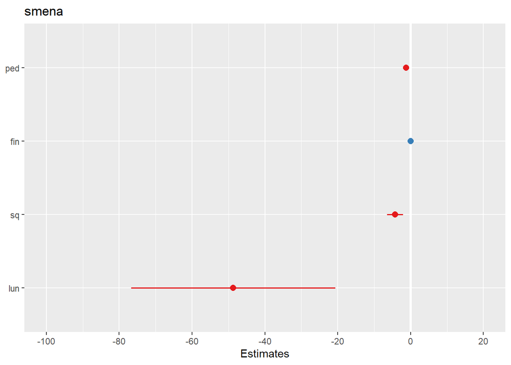

```r
plot_model(model)
```